# lab_05_Yerim_Oh

### Question 5

Using that method, estimate `modifier` from `observations`. Name your estimate `min_estimate`.

```python
min_estimate = min(observations)-1
min_estimate
```

```
17.0
```

Another way to estimate the modifier involves the mean of `observations`.

### Question 6

Figure out a good estimate based on that quantity. **Then**, write a function named `mean_based_estimator` that computes your estimate. It should take an array of modified rolls (like the array `observations`) as its argument and return an estimate of `modifier` based on those numbers.

```python
def mean_based_estimator(nums):
    """Estimate the roll modifier based on observed modified rolls in the array nums."""
    mean_estimate = np.average(nums)-10.5
    return mean_estimate

# Here is an example call to your function.  It computes an estimate
# of the modifier from our 7 observations.
mean_based_estimate = mean_based_estimator(observations)
mean_based_estimate
```

```
12.928571428571427
```

### Question 7

Recall the warplanes estimation problem from lecture. There, it made sense to multiply the mean by 2 to estimate the largest serial number. That doesn't make sense for this estimation problem. Why not?

Answer:

Now we want to know how well our two estimators work. To do that, we'll imagine what *could have happened* when we got our observations. Concretely, that means we'll generate new sets of observations 1000 times (that is, 1000 times, we'll simulate 7 modified rolls). Each time, we'll use both estimators to compute estimates of the modifier for each simulated observation set. Then, we'll display the distribution of those estimates. That will show us how often each estimator does how well.

### Question 8

Write code to compute a table called `estimates`. It should have 1000 rows and 2 columns. Each row should correspond to a different sample of 7 simulated modified rolls. The first column, `"min estimate"`, should contain estimates using the `min` of each sample. The second column, `"mean-based estimate"`, should contain estimates using your `mean_based_estimator` function on each sample.

```python
min_estimates = make_array()
mean_based_estimates = make_array()
for i in range(1000):
    new_observations = simulate_observations()
    new_min_estimate = min(new_observations)-1
    new_mean_based_estimate = mean_based_estimator(new_observations)
    min_estimates = np.append(min_estimates, new_min_estimate)
    mean_based_estimates = np.append(mean_based_estimates, new_mean_based_estimate)

estimates = Table().with_columns("min estimate", min_estimates,
                                 "mean-based estimate", mean_based_estimates)
estimates
```

| min estimate | mean-based estimate |
| --- | --- |
| 15 | 10.0714 |
| 11 | 10.3571 |
| 11 | 10.3571 |
| 12 | 10.3571 |
| 12 | 13.0714 |
| 16 | 10.0714 |
| 11 | 12.2143 |
| 15 | 10.9286 |
| 13 | 9.5 |
| 14 | 10.7857 |

... (990 rows omitted)

### Question 9

Make a plot of the empirical distributions of both statistics. (You should make a *single plot* containing two histograms. Calling the `hist` method of a table that has 2 numerical columns will do this.)

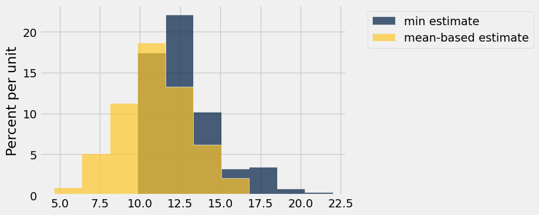

```python
#Make your histogram here
estimates.hist()
```

### Question 10

Answer: Because there are 1 to 20 numbers that can come out from the die and if we add 11, the numbers are larger. The chance of getting the die 1 when we roll the die once is 1/20. Since the min-based estimates subtract 1 from the minimum observation, most of the numbers would be larger than the actual modifier. However, the mean-based estimates are the result of subtracting the average of the die from the average of the observations. Therefore, this would be closer to the actual modifier which makes most of the mean-based estimates being smaller than the min-based estimates.

## 2. *Swain v. Alabama*

In lecture, we tested the hypothesis that a jury panel in Alameda County was a random sample from the population of Alameda. Let's go through a similar example in another context.

##### Background

Swain v. Alabama was a US Supreme Court case decided in 1965. A black man, Swain, was accused of raping a white woman, and had been convicted by an all-white jury. The jury was selected from a panel of 100 people that contained only 8 black people and 92 people of other ethnicities. That panel was supposed to be a random sample from the eligible population of Talladega County, which was 26% black and 74% other ethnicities (and, by law, all male). We will assume there were 16,000 people in all of Talladega County eligible to serve on the jury.

Swain's lawyers argued that this reflected a bias in the jury panel selection process. A five-justice majority of the Supreme Court disagreed, asserting that,

> "The overall percentage disparity has been small and reflects no studied attempt to include or exclude a specified number of Negros."

Is 8 enough smaller than 26 to indicate that the jury panel wasn't just a random sample from the eligible population?

It *could* have happened by chance, so this may seem like a judgement call. Indeed, five Supreme Court justices apparently thought it was a matter of judgement.

In fact, with a computer simulation, we can answer that is is very unlikely to see a panel of 8 randomly selected from this population. (Note that the scarcity of computers at the time was no excuse. Any statistician could have done this calculation by hand in 1965.)

Here are the data:

| Ethnicity | Number eligible | Number in panel |
| --- | --- | --- |
| Black | 4160 | 8 |
| Other | 11840 | 92 |

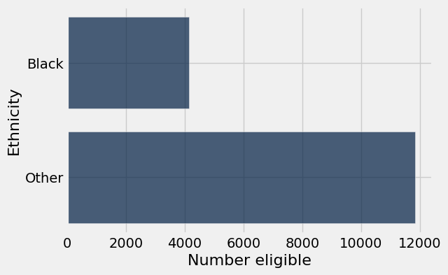

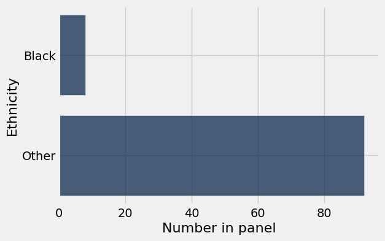

```python
jury = Table.read_table("~/DS_113_S23/Labs/Lab_5/jury.csv")
jury.barh('Ethnicity', "Number eligible")
jury.barh('Ethnicity', "Number in panel")
jury
```

### Question 1

It's helpful to draw both bars in one plot to really see the visual distinction. Why would this not be a good idea with the data that we have so far? Think about what the bar graphs would look like if we plotted them all onto the same chart.

Answer: The largest number is 11840 and the smallest number is 8. If we draw both bars in one plot, we cannot see the amount for the number in panel.

### Question 2

Fix the problem by making one bar chart displaying the *proportions* of ethnicities among the eligible population and the panel. **Before you make the chart**, create a table called `with_proportions` that's a copy of `jury` with columns containing these proportions. (The column names are filled in for you.)

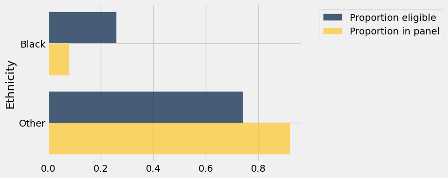

```python
with_proportions = jury.with_columns(
        "Proportion eligible", (jury["Number eligible"]/sum(jury["Number eligible"])),
        "Proportion in panel", (jury["Number in panel"]/sum(jury["Number in panel"])))
with_proportions.select("Ethnicity","Proportion eligible","Proportion in panel").barh('Ethnicity')
```

To test the hypothesis that the actual panel was a random sample from the eligible population, we first write down a *null hypothesis*. We will imagine (via computer simulation) what the data would typically look like if this hypothesis were true. If the actual data don't look like that, we'll reject the null hypothesis.

Our null hypothesis is straightforward:

> **Null hypothesis:** "The actual panel in Swain's trial was a random sample from the eligible population in Talladega County."

```python
def proportions_from_distribution(table, proportions_column_label, sample_size):
    """Produces a random sample with replacement, using proportions from the
    column named proportions_column_label in the given table.  The size of the
    sample is sample_size.

    Each row in the given table should represent one kind of thing.
    Each kind of thing has a proportion, which is the chance that each
    member of the sample is that kind.

    Returns a copy of table with an extra column called "Proportion in random
    sample".  This column contains the number of elements of each kind that
    ended up in the random sample."""
    proportions = np.random.multinomial(sample_size, table.column(proportions_column_label))/sample_size
    return table.with_column("Proportion in random sample", proportions)

# Sampling 1 person:
one_random_sample = proportions_from_distribution(with_proportions, "Proportion eligible", 100)
one_random_sample
```

| Ethnicity | Number eligible | Number in panel | Proportion eligible | Proportion in panel | Proportion in random sample |
| --- | --- | --- | --- | --- | --- |
| Black | 4160 | 8 | 0.26 | 0.08 | 0.21 |
| Other | 11840 | 92 | 0.74 | 0.92 | 0.79 |

If we repeated this many times, about 26% of the time we'd get a black person. Let's try that out.

### Question 3

Write a function called `simulate_single_samples`. It should take no arguments and return no value. It should simulate 10000 single draws and produce a *histogram* of the numbers of black people in each of those draws.

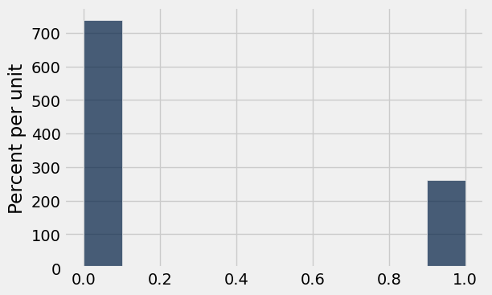

```python
def simulate_single_samples():
    samples = make_array()
    for i in np.arange(10000):
        simulate_sample = proportions_from_distribution(with_proportions, "Proportion eligible", 1)
        samples = np.append(samples, simulate_sample.column(5).item(0))
    Table().with_column("", samples).hist()

simulate_single_samples()
```

Let's see what happens when we sample 100 people instead of just 1. Remember, this is simulating how jury panels were *supposed* to be selected, according to the law.

### Question 4

Call `proportions_from_distribution` to create a table called `one_sample_of_100` that represents one sample of 100 people from among the eligible jurors. This is one panel we could see *if the null hypothesis were true*. **Then,** make a single bar chart displaying the proportions of ethnicities in this sample, in the eligible population, and in the actual panel in Swain's case.

| Ethnicity | Number eligible | Number in panel | Proportion eligible | Proportion in panel | Proportion in random sample |
| --- | --- | --- | --- | --- | --- |
| Black | 4160 | 8 | 0.26 | 0.08 | 0.33 |
| Other | 11840 | 92 | 0.74 | 0.92 | 0.67 |

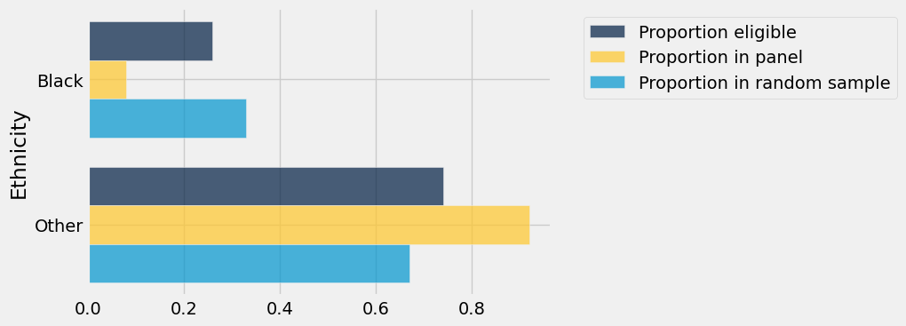

```python
one_sample_of_100 = proportions_from_distribution(with_proportions, "Proportion eligible", 100)
one_sample_of_100.show()
one_sample_of_100.drop(1,2).barh("Ethnicity")
```

Does the panel look like it could have come from this process?

To answer that question, we'll need to sample many times, not just once. And we'll need to summarize each sample with a number (a "test statistic"). We want the number to generally look one way if the null hypothesis is true, and some other way if it's not.

A useful test statistic in cases like this is the *total variation distance* (TVD) between the distribution of ethnicities in the sample and the distribution of ethnicities in the eligible population. Intuitively, this distance should be typically small if the null hypothesis is true, because many samples will have similar proportions of ethnicities as the population from which they're taken.

To compute the TVD visually, make a bar chart of the two distributions, like the one you made above (ignoring the bars displaying the proportions in the panel). Then for each category ("Black" and "Other"), find the absolute difference between the lengths of the bars. Add up those absolute differences, and divide by 2.

### Question 5

Look at the bar chart you made above. Without using any code, estimate the TVD between the distribution of ethnicities in the sample and the distribution of ethnicities in the eligible population. Then estimate the TVD between the distribution of ethnicities in the *actual panel* and the distribution of ethnicities in the eligible population. Note which one is bigger. Check with a neighbor or a TA to verify your answer.

```python
rough_tvd_between_sample_and_population = 0.07
rough_tvd_between_panel_and_population = 0.18
```

### Question 6

Write a function called `tvd_from_eligible_population`. It should take 1 argument: an array of proportions of ethnicities. The first element in the array is the proportion of black people, and the second element in the array is the proportion of others. The function should return the TVD between that distribution of ethnicities and the distribution in the eligible population.

```python
def tvd_from_eligible_population(proportions):
    difference_black = abs(proportions.item(0) - one_random_sample.column(3).item(0))
    difference_other = abs(proportions.item(1) - one_random_sample.column(3).item(1))
    return ((difference_black+difference_other) / 2)


# An example call to your function.  This computes the
# TVD you estimated in question 5.
print("TVD between eligible population and a random sample:", tvd_from_eligible_population(one_sample_of_100.column("Proportion in random sample")))
# ...and this computes the other TVD you estimated.
print("TVD between eligible population and the actual panel:", tvd_from_eligible_population(with_proportions.column("Proportion in panel")))
```

[output not shown]

Now you have all the ingredients for running an hypothesis test:

1. You can generate data you would see if the null hypothesis were true. You did that once in question 4.
2. You can compute a test statistic on each simulated dataset by calling `tvd_from_eligible_population`.

### Question 7

Write a function called `simulate_tvds_under_null`. It should take no arguments and return no value. It should run **20,000** simulations under the null hypothesis, compute the test statistic for each one, and produce a histogram of those **20,000** test statistics.

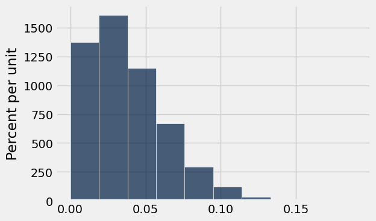

```python
def simulate_tvds_under_null():
    stat_array = make_array()
    for i in np.arange(20000):
        sample_100 = proportions_from_distribution(with_proportions, "Proportion eligible", 100)
        test_statistic = tvd_from_eligible_population(sample_100.column(5))
        stat_array = np.append(stat_array, test_statistic)
    Table().with_column("", stat_array).hist()

simulate_tvds_under_null()
```

Run the cell below to see the results of your simulation augmented with a red line that shows the TVD between the actual panel and the eligible population (which you estimated in question 5).

[figure not shown]

```python
# You don't need to read this function unless you're interested.
def draw_red_line(spot, height, description):
    """Draw a vertical red line at a spot in a graph."""
    plt.plot([spot, spot], [0, height], color="red", label=description)
    # Draw a legend off to the right to explain the red line.
    plt.legend(loc="center left", bbox_to_anchor=[1, .5])

# Now we'll redraw our histogram and draw a line at the observed TVD.
simulate_tvds_under_null()
draw_red_line(tvd_from_eligible_population(with_proportions.column("Proportion in panel")), 1000, "TVD between Swain's\nactual jury panel and\nthe eligible population")
```

### Question 8

Do we have evidence for or against the null hypothesis, or not much evidence either way? Discuss with a neighbor or a TA.